# ESA 2015 APPENDIX

Jeff Atkins

Monday, August 10, 2015

I have included a few extras here that are in addition to my conference poster, including some addition incomplete analysis and expanded statistics.

A brief note on plot design. There are three elevation classes (HIGH, MID, LOW) and three vegetation classes (CANOPY, SHRUB, OPEN). These are explained on the poster and in Atkins et al. 2015. There are replicates of each combination for 27 total plots. This means there is a HIGH CANOPY ONE, HIGH CANOPY TWO, HIGH CANOPY THREE . . . and so on for each other combination. Those are abbreviated here (HIGH CANOPY = HC, LOW OPEN = LO, etc.)

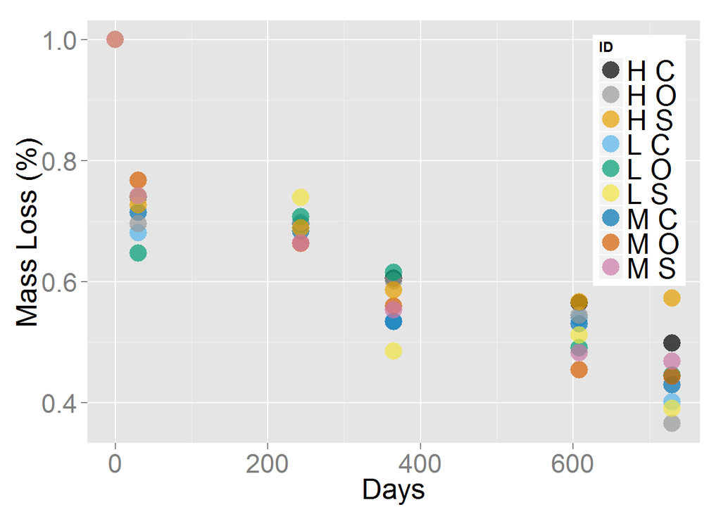

In the above graph, the 27 plots in the study aggregated by ELEVATION * VEGETATION (HC, LO, etc), therefore each point represents a total of three plots. While not definitive, this plot does show the sinusoidal pattern that is influenced by seasonality. This is preliminary attributed to heavy snowfall contribution to increased decomposition the first winter, and lack of snowfall limiting snowfall in the second winter. Confounding this interpretation is the simple fact that there is less mass the second winter. However, the strong seasonal pattern belies the typical exponential model of decomposition.

```
  VEG p-value
1   0.3961644
2   0.6656891
3   0.6796051
4   0.1969351
5   0.4093591
```

```
  ELEV p-value
1   0.02003944
2   0.32250144
3   0.02054040
4   0.05343077
5   0.05425527
```

P-values from Kruskal-Wallis tests on both elevation and vegetation treatments.

Several months (over a year now, depressingly) went into trying to analyze and quantify lignin concentrations from both the leaves and additional treatments that were at each plot. The method I chose ended up not being a perfect match for the equipment we had on hand, but by August of 2015 I had it up and working with the help of Meg Miller, our indomitable department lab tech. Some of the preliminary lignin data is shown here. Due to the LENGTHY processing time, I don’t have all of it completed.

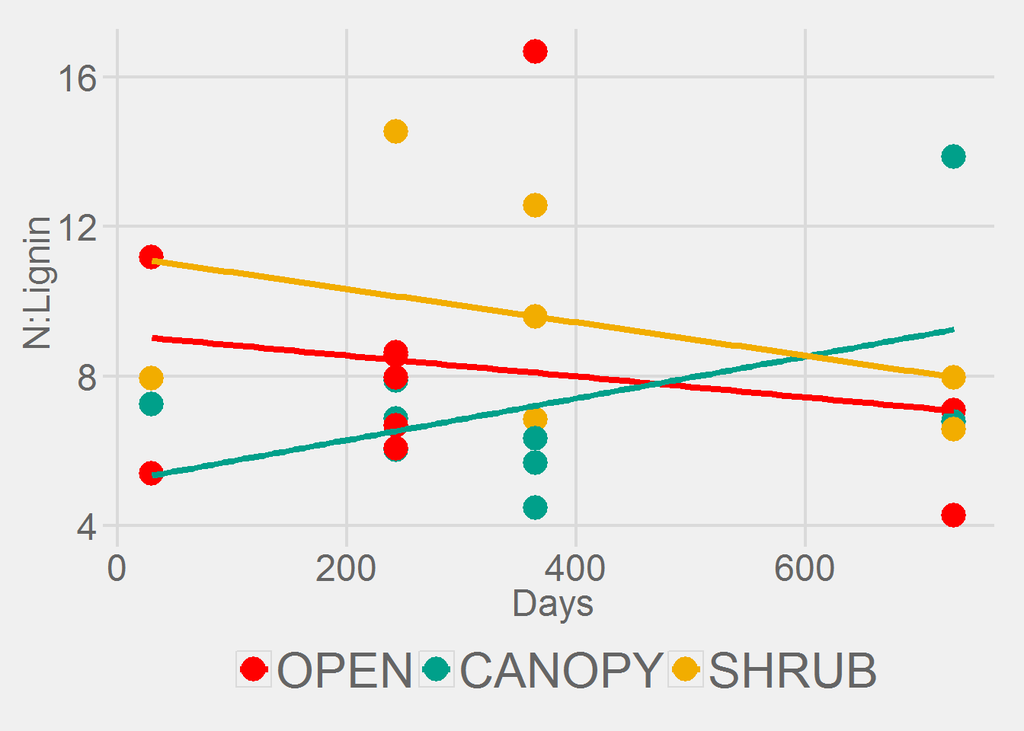

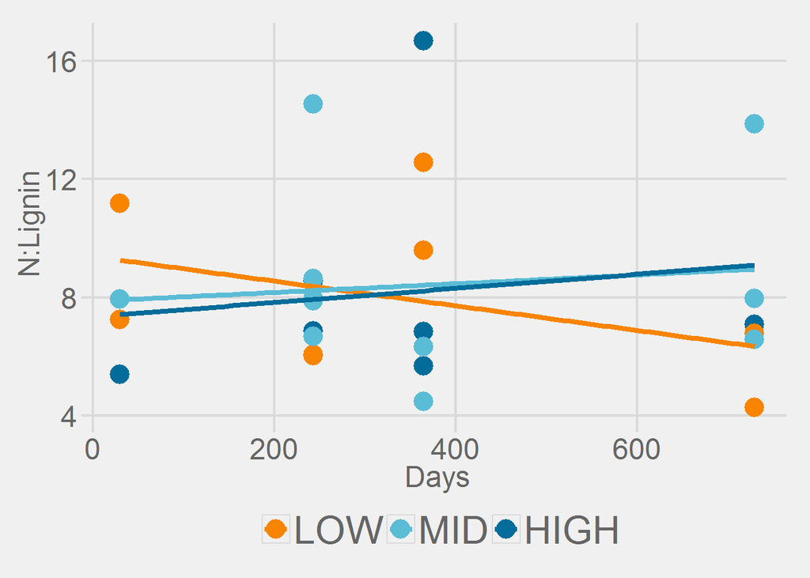

There is a lot of spread here, but the numbers are reasonable. This represents a small portion of the data set, but is coming along. Also, ignore the lines. A code relic that knitr or Markdown won’t let go of despite removal from source code.

Source code not on github yet, but will be once analysis is finished and paper is submitted for review. Comments or suggestions always welcome (@atkinsjeff or jeffatkins@virginia.edu)